# Juzgamiento de hipótesis

# Tamaño del efecto.

El tamaño del efecto se contempla como una medida que complementa la prueba de hipótesis.

Imagine que estamos comparando un grupo de personas que recibe un tratamiento para disminuir la ansiedad y un grupo que no (grupo control).

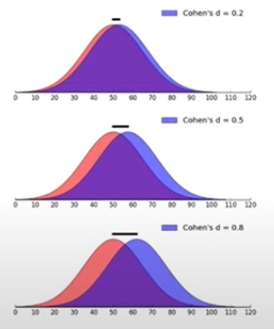

Cuando se analiza la prueba de hipótesis, lo único que dice es la probabilidad de que las diferencias que se estan observando se deban al azar o no, lo cual lo indica el valor de p, entonces si la probabilidad es baja(p-valor) es decir si la probabilidad de que esa diferencia sea al azar es bajo entonces rechazo la hipótesis nula. En cambio si la probabilidad de que esa diferencia se deba al azar es alta, se acepta la hipótesis nula en función si el valor p es mayor o menor a 0,05.

Ahora supongase que se hace un aprueba de hipótesis se elige un buen tamaño muestral y se obtiene que efectivamente la media de una distribución se deiferencia de la media de otra distribución y que esas diferencias efectivamente no son iguales sino que hay diferencias que son estadísticamente significativas es decir que no se explican por azar, entonces rechazo la hipótesis nula y digo que esas diferencias no se deben al azar.

Ahora en los tres casos(gráficas) se rechaza la hipótesis nula; las diferencias no se deben al azar, efectivamente estas distribuciones no son iguales. Sin embargo puede ocurrir que hay una diferencia estadísticamente significativa; las personas que hacen el tratamiento disminuyen su nivel de ansiedad, pero de ahi a decir que el tratamiento es bueno o que el tratamiento genera una diferencia fuerte hay una distancia, es decir lo que indica la medida del **tamaño del efecto** tiene que ver con la magnitud de esa diferencia.

En otras palabras la prueba de hipótesis solamente nos dice si la diferecia que se esta observando se debe o no al azar,entonces supongamos que decidimos rechazar la hipótesis nula(p-valor < $\alpha$) efectivamente las diferencias que se estan observando no se deben al azar, pero surge la siguiente pregunta:

¿Cuan fuerte son esas diferencias?

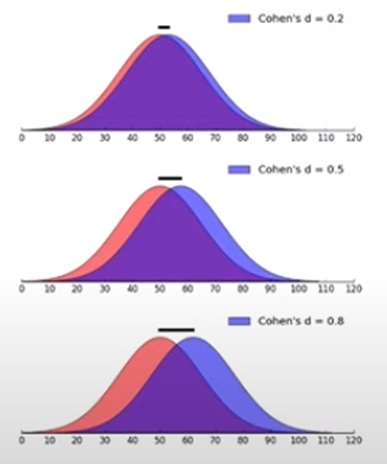

Hay un procedimiento estadístico que se usa mucho que es la **d de Cohen** que se usa justamente para medir la magnitud de esa diferencia y está dada por medio de la siguiente fórmula:

$d = \frac{\overline{X}_{t} - \overline{X}_{c} }{\sigma_{pooled}}$

donde $\overline{X}_{t}$ es la media de los pacientes que recibieron el tratamiento, $\overline{X}_{c}$ es la media de los pacientes control y

$\sigma_{pooled} = \sqrt{\frac{(n_{t} - 1)s_{t}^{2}+(n_{c} - 1)s_{c}^{2} }{n_{t}+n_{c}}}$

donde

- $n_{t}$ es el número de pacientes que recibe el tratamiento.
- $n_{c}$ es el número de pacientes control.
- $s_{c}$ desviación estándar de los pacientes control.
- $s_{t}$ desviación estándar de los pacientes que reciben el tratamiento.

La fórmula anterior se utiliza cuando las desviaciones estándar (o típicas) de nuestros grupos son diferentes.

Cada vez que se pone a prueba un tratamiento no solo se debe ver si las diferecias que genera se deben o no al azar lo cual se hace a través de la prueba de hipótesis, además se debe indicar la magnitud del efecto es decir en que medida cual es la magnitud de esa diferencia que se genera entre el grupo que recibe el tratamiento y el que no.

En el tratamiento genera diferencias que no se deben al azar, sino que ademásse tiene que dar información de cual es la magnitud del efecto de ese tratamiento y para eso se usa la **d de Cohen.**

Si la de d de Cohen es:

- 0.20 indica un tamaño del efecto debíl.
- 0.5 indica un tamaño del efecto moderado.
- 0.8 o superior indica un tamaño del efecto elevado.

Hay otras muchas medidas del tamaño del efecto pero la más popular es la d de Cohen.

# ¿Para que se usa el tamaño del efecto?

Se usa para dos cosas:

- Para cuantificar la magnitud de la diferencia que genera un trtamiento.
- Para llevar desarrollar meta- análisis: que es un tipo de estudio en donde se comparan las medidas del tamaño del efecto de diferentes investigaciones sobre un mismo tema.

Ejemplo

**“A meta-analysis of group Cognitive Behavioral Therapy (CBT) interventions for adolescents with depression”**

El cual se puede encontrar en las bases de datos de la universidad. (elsevier)

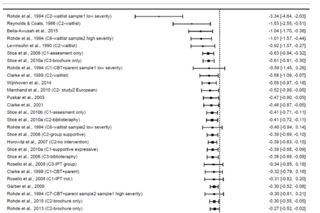

# Programas.

- A priori, para determinar el tamaño de muestra que necesitarias para evitar cometer un error de tipo II.
- A posteriori, en caso de no enontrar resultados estadisticamente significativos para determinar la probabilidad de haber cometido unn error tipo II.

[Sample Size Calculators](https://sample-size.net/sample-size-means/)

[figure not shown]

[Link de descarga de G*power](https://www.psychologie.hhu.de/arbeitsgruppen/allgemeine-psychologie-und-arbeitspsychologie/gpower)

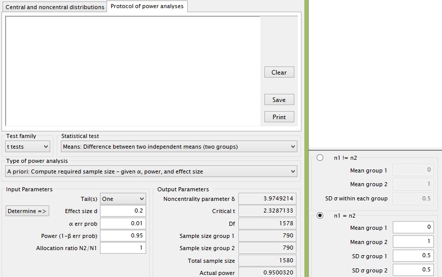

[Openepi](https://www.openepi.com/Menu/OE_Menu.htm)